# PersonalFinalProject

Since I've participated in other PI's final project, I wanted to try on the topic I've suggested.

My final project proposal's title was 'Bellman-Ford Algorithm for Negative Weight Edges in Graphs.' Bellman-Ford algorithm is for negative weight edges, so I wanted to find some examples of it in biology or ecology and bring out some good intuition through that. However, it was not easy to find chemical reaction that have more than three elements(which would be three nodes in my work), that contains negative energy entry. Instead, I found carbon equilibrium graph that contains the carbon flux information and thought it would be interesting to deal with that.

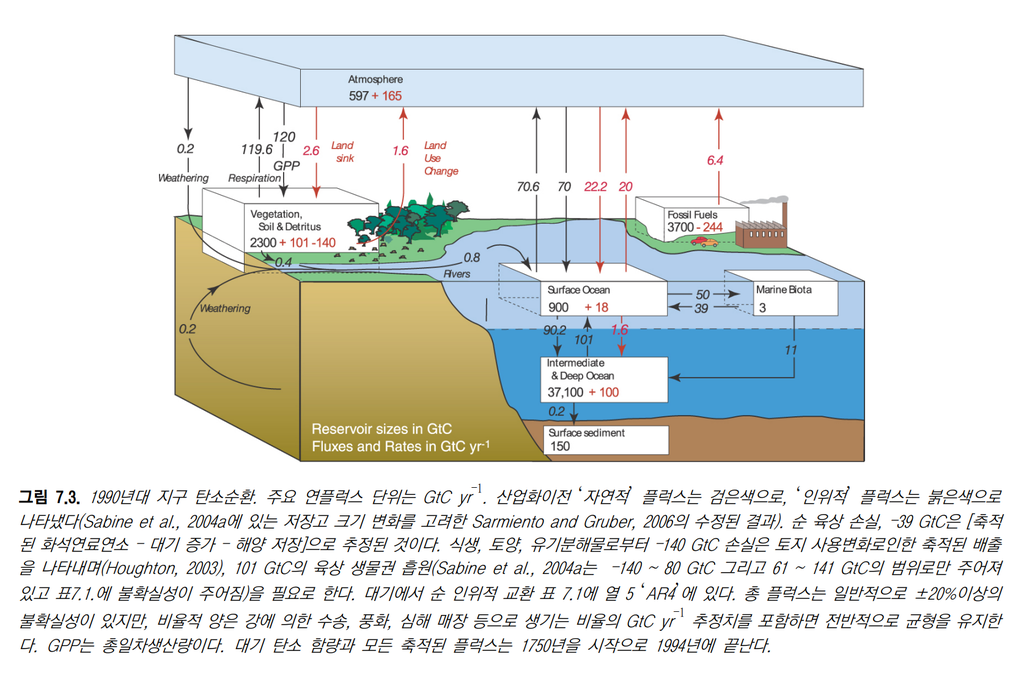

It is a visualization of **carbon circulation** in 1990's. It divides environmental elements that contains carbons, such as atmosphere, ocean, vegetation, and fossil fuel. Carbon fluxes are showed with arrow and the unit is *GtC/year*. **Fluxes** can be simply understood as entry and flow, and **GtC** is Gigatons of Carbons. The **black arrows** represent natural fluxes and the **red arrows** represents human-made fluxes. I tried to simplify this to a graph form like below.

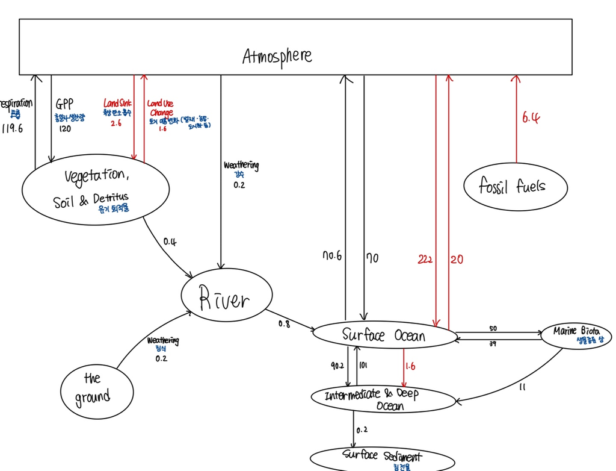

I think the important features about this graph is that,

1. The edges are directed
2. There are more than one edges between some of the vertices
3. There is distinction between natural and man-made fluxes